# Description of Samples and Populations

## Introduction

**Variable**: a characteristic of a person or a thing that can be assigned a number or a category.

- *Categorical variable*: a variable that records which of several categories a person or thing is in, either nominal or ordinal.
  - Gender (male, female), eye color (blue, brown, green), or country of origin (USA, Canada, UK).
  - Educational attainment (elementary, high school, college, postgraduate) or Likert scale responses (strongly disagree, disagree, neutral, agree, strongly agree).
- *Numeric variable*: a variable that records the amount of something, either continuous or discrete.
  - Weight of a baby.
  - Cholesterol concentration in a blood specimen.
  - Number of bacteria colonies in a petri dish.
  - Length of a DNA segment in basepairs.

## Frequency Distributions

**Frequency distribution**: a display of the frequency, or number of occurrences, of each value in the data set.

### Example: color of poinsettias

Poinsettias can be red, pink, or white. In one investigation of the hereditary mechanism controlling the color, 182 progeny of a certain parental cross were categorized by color.

- Table:

| Color | Frequency (number of plants) |
| --- | --- |
| Pink | 34 |
| Red | 108 |
| White | 40 |
| Total | 182 |

- Bar chart:

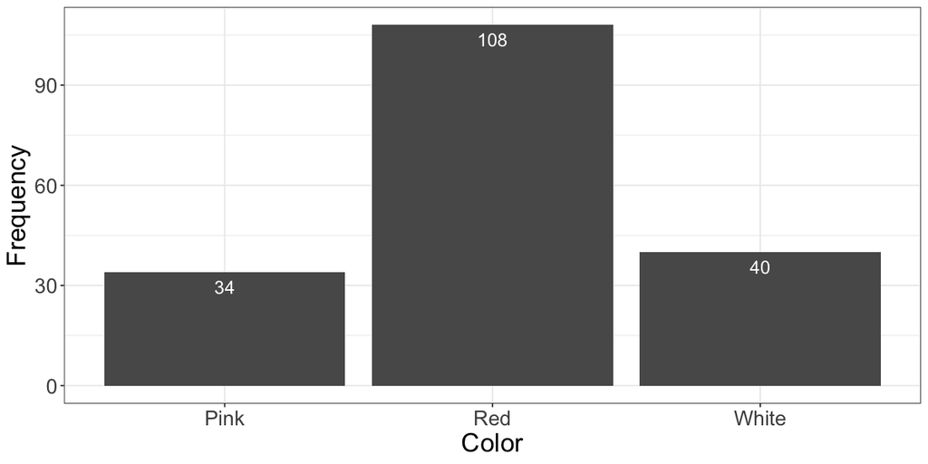

```r
library(ggplot2)
g <- ggplot(data = data.frame(Frequency = c(108, 34, 40), Color = c('Red', 'Pink', 'White')), aes(x = Color, y = Frequency)) +
    geom_bar(stat="identity") +
    geom_text(aes(label = Frequency), vjust = 1.6, color = "white", size = 5)+
    theme_bw() +
    theme(text = element_text(size = 20))
options(repr.plot.width=10, repr.plot.height=5)
g
```

### Example: infant mortality

The following table shows the infant mortality rate (infant deaths per 1,000 live births) in each of seven countries in South Asia, as of 2013.

| Country | Infant mortality rate (deaths per 1,000 live births) |
| --- | --- |
| Bangladesh | 47.3 |
| Bhutan | 40.0 |
| India | 44.6 |
| Maldives | 25.5 |
| Nepal | 41.8 |
| Pakistan | 59.4 |
| Sri Lanka | 9.2 |

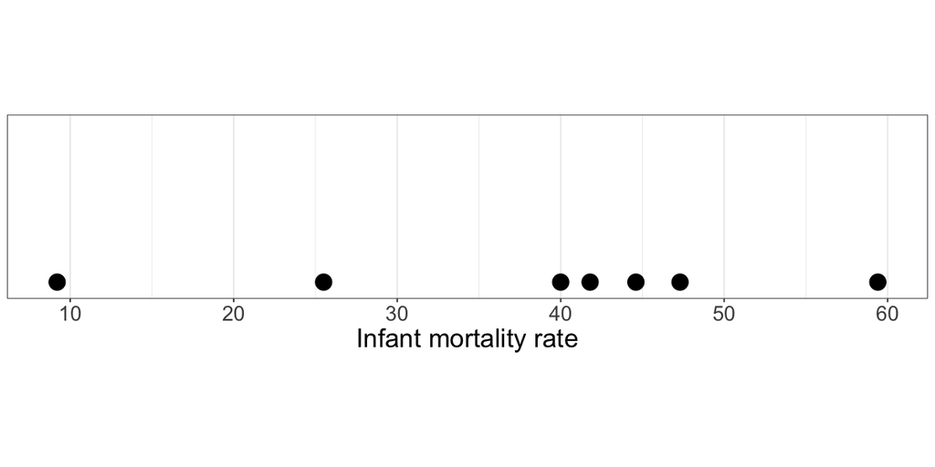

```r
g <- ggplot(data = data.frame(x = c(47.3, 40.0, 44.6, 25.5, 41.8, 59.4, 9.2)), aes(x = x)) +
    geom_dotplot(binwidth = 1) +
    scale_x_continuous(name = 'Infant mortality rate', breaks = seq(10, 60, 10)) +
    scale_y_continuous(NULL, breaks = NULL) +
    theme_bw() +
    theme(text = element_text(size = 20), aspect.ratio=1/5)
options(repr.plot.width=10, repr.plot.height=5)
g
```

### Relative frequency

The frequency scale is often replaced by a relative frequency scale: $$\text{Relative frequency} = \frac{\text{Frequency}}{n}$$ As another option, a relative frequency can be expressed as a percentage frequency.

| Color | Frequency (number of plants) | Relative frequency | Percent frequency |
| --- | --- | --- | --- |
| Pink | 34 | .19 | 19 |
| Red | 108 | .59 | 59 |
| White | 40 | .22 | 22 |
| Total | 182 | 1.00 | 100 |

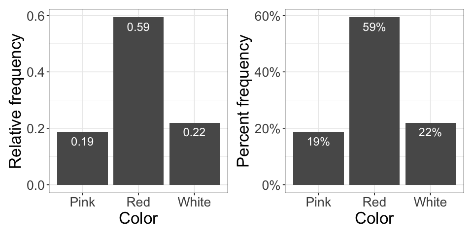

```r
g1 <- ggplot(data = data.frame(Frequency = c(108, 34, 40), Color = c('Red', 'Pink', 'White')), aes(x = Color, y = Frequency / sum(Frequency))) +
    geom_bar(stat="identity") +
    geom_text(aes(label = round(Frequency / sum(Frequency), 2)), vjust = 1.6, color = "white", size = 5)+
    labs(y = 'Relative frequency') +
    theme_bw() +
    theme(text = element_text(size = 20))
g2 <- ggplot(data = data.frame(Frequency = c(108, 34, 40), Color = c('Red', 'Pink', 'White')), aes(x = Color, y = Frequency / sum(Frequency))) +
    geom_bar(stat="identity") +
    geom_text(aes(label = paste0(100 * round(Frequency / sum(Frequency), 2), '%')), vjust = 1.6, color = "white", size = 5)+
    scale_y_continuous(name = 'Percent frequency', labels=scales::percent) +
    theme_bw() +
    theme(text = element_text(size = 20))
library(patchwork)
options(repr.plot.width=8, repr.plot.height=4)
g1 + g2
```

### Grouped frequency distributions and histograms

For many data sets, it is necessary to group the data in order to condense the information adequately. (This is usually the case with continuous variables.)

### Example: forced expiratory volume in children

A total of 654 children, comprising 336 boys and 318 girls, underwent examination to measure their forced expiratory volume in liters.

```
Female   Male
   318    336
```

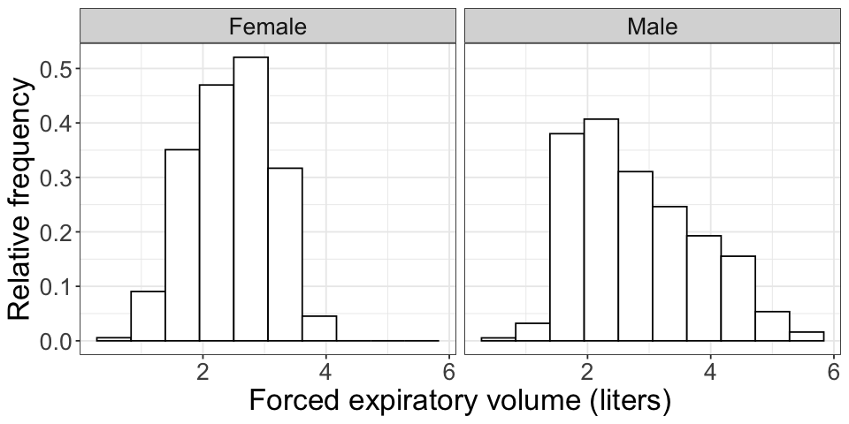

```r
library(isdals)
data(fev)
fev$Gender <- ifelse(fev$Gender == 0, 'Female', 'Male')
table(fev$Gender)
g <- ggplot(data = fev, aes(x = FEV, y = ..density..)) +
    geom_histogram(color="black", fill = 'white', bins = 10) + # can also change bins to obtain finer or coarser histograms
    labs(x = "Forced expiratory volume (liters)", y = "Relative frequency") +
    facet_wrap(~Gender) +
    theme_bw() +
    theme(text = element_text(size = 20))
options(repr.plot.width=8, repr.plot.height=4)
g
```

When discussing a set of data, we want to describe the shape, center, and spread of the distribution. The shape of a distribution can be indicated by a smooth curve that approximates the histogram.

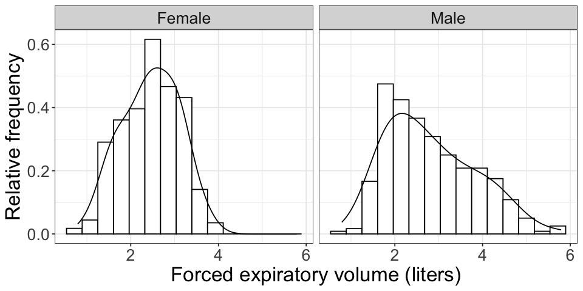

```r
g <- ggplot(data = fev, aes(x = FEV, y = ..density..)) +
    geom_histogram(color="black", fill = 'white', bins = 15) + # can also change bins to obtain finer or coarser histograms
    geom_density(adjust = 1.5) +
    #geom_vline(aes(xintercept = mean(FEV)), col = 'orange')+
    #geom_vline(aes(xintercept = median(FEV)), col = 'skyblue')+
    labs(x = "Forced expiratory volume (liters)", y = "Relative frequency") +
    facet_wrap(~Gender) +
    theme_bw() +
    theme(text = element_text(size = 20))
options(repr.plot.width=8, repr.plot.height=4)
g
```

### Shapes of distributions

A common shape for biological data is unimodal (has one mode) and is somewhat skewed to the right, as in (c). Approximately bell-shaped distributions, as in (a), also occur. Sometimes a distribution is symmetric but differs from a bell in having long tails; an exaggerated version is shown in (b). Left-skewed (d) and exponential (e) shapes are less common. Bimodality (two modes), as in (f), can indicate the existence of two distinct subgroups of observational units.

[figure not shown]

### How to tell if a distribution is left skewed or right skewed

A skewed distribution occurs when one tail is longer than the other. Skewness defines the asymmetry of a distribution.

- Skewed to the right: The mean is **greater** than the median.
- Skewed to the left: The mean is **less** than the median.
  - The **mean** is the average of a data set.
  - The **mode** is the most common number in a data set.
  - The **median** is the middle of the set of numbers.

[figure not shown]

```r
# orange solid: mean
# blue dashed: median
library(patchwork)
options(repr.plot.width=20, repr.plot.height=5)
g1 + g2 + g3
```

## Descriptive Statistics: Measures of Center

- A numerical measure calculated from sample data is called a **statistic**.
- **Descriptive statistics** are statistics that describe a set of data.
- Usually the descriptive statistics for a sample are calculated in order to provide information about a population of interest.
- Two most widely used measures of center: the **median** and the **mean**.

### Median $\tilde{y}$

- The sample median is the value that most nearly lies in the middle of the sample, i.e., the data value that splits the ordered data into two equal halves.
- To find the median, first arrange the observations in increasing order. In the array of ordered observations, the median is the middle value (if $n$ is odd) or midway between the two middle values (if $n$ is even).

### Example: weight gain of lambs

- The following are the 2-week weight gains (lb) of six young lambs of the same breed that had been raised on the same diet:
  - 11 13 19 2 10 1
- Suppose the sample contained one more lamb, with 2-week weight gains (lb) being 10.

A more formal way to define the median is in terms of rank position in the ordered array (counting the smallest observation as rank 1, the next as 2, and so on). The rank position of the median is equal to $(0.5)(n + 1)$. Note that the formula $(0.5)(n + 1)$ does not give the median, it gives the location of the median within the ordered list of the data.

## Mean $\bar{y}$

- The most familiar measure of center is the ordinary average or mean (sometimes called the arithmetic mean).
- The mean of a sample (or "the sample mean") is the sum of the observations divided by the number of observations.
- The general definition of the sample mean is $\bar{y}=\frac{1}{n}\sum_{i=1}^ny_i$, where the $y_i$ are the observations in the sample and $n$ is the sample size.

### Example: weight gain of lambs

- The following are the 2-week weight gains (lb) of six young lambs of the same breed that had been raised on the same diet:
  - 11 13 19 2 10 1

### Robustness

A statistic is said to be robust if the value of the statistic is relatively unaffected by changes in a small portion of the data, even if the changes are dramatic ones.

Recall that for the lamb weight-gain data,

- if the observation 19 is changed 14, the mean becomes 8.5 and the median does not change;
- if the observation 19 is changed 29, the mean becomes 11 and the median does not change.

### Median v.s mean

- While the median divides the data into two equal pieces (i.e., the same number of observations above and below), the mean is the "point of balance" of the data.
- The median is more robust than the mean.
- An advantage of the mean is that in some circumstances it is more efficient than the median. Partly because of its efficiency, the mean has played a major role in classical methods in statistics.
- If the frequency distribution is symmetric, the mean and the median are equal and fall in the center of the distribution. If the frequency distribution is skewed, both measures are pulled toward the longer tail, but the mean is usually pulled farther than the median.

[figure not shown]

## Boxplots

One of the most efficient graphics, both for examining a single distribution and for making comparisons between distributions, is known as a boxplot.

### Quartile and the interquartile range

- The median of a distribution splits the distribution into two parts, a lower part and an upper part. The quartiles of a distribution divide each of these parts in half, thereby dividing the distribution into four quarters.
- The minimum, the maximum, the median, and the quartiles, taken together, are referred to as the **five-number summary** of the data.

### Example: blood pressure

- The systolic blood pressures (mm Hg) of seven middle-aged men were as follows:
  - 151 124 132 170 146 124 113

[figure not shown]

- Suppose one more observation 130 is added in the sample.

### Interquartile range

The interquartile range is the difference between the first and third quartiles and is abbreviated as IQR, which measures the spread of the middle 50\% of the distribution.

$$\mathrm{IQR}=Q_3-Q_1$$

Recall that for the blood pressure data, $Q_1=124$ and $Q_3=151$. It follows that $\mathrm{IQR}=151-124=27$.

### Outliers

- Sometimes a data point differs so much from the rest of the data that it doesn't seem to belong with the other data. Such a point is called an outlier.
- An outlier might occur because of a recording error or typographical error when the data are recorded, because of an equipment failure during an experiment, or for many other reasons.

To given a definition of outlier, we first discuss what are known as fences.

- The **lower fence** of a distribution is $$\text{lower fence}=Q_1-1.5\times\mathrm{IQR}$$
- The **upper fence** of a distribution is $$\text{upper fence}=Q_3+1.5\times\mathrm{IQR}$$

An outlier is a data point that falls outside of the fences. That is, if $$\text{data point}<Q_1-1.5\times\mathrm{IQR}$$ or $$\text{data point}>Q_3+1.5\times\mathrm{IQR}$$ then we call the point an outlier.

Recall that for the blood pressure data, $Q_1=124$, $Q_3=151$, and $\mathrm{IQR}=27$. It follows that the lower fence is $124-1.5\times27=83.5$ and the upper fence is $151+1.5\times27=191.5$. Any point less than $83.5$ or greater than $191.5$ would be an outlier. There is thus no outliers in this data set.

### Example: radish growth in light

A common biology experiment involves growing radish seedlings under various conditions. In one experiment students grew 14 radish seedlings in constant light. The observations, in order, are

[figure not shown]

### Boxplots for data with no outliers

A boxplot is a visual representation of the five-number summary.

[figure not shown]

### Boxplots for data with outliers

If there are outliers in the lower or upper part of the distribution, we identify them with dots and extend a whisker from $Q_1$ down to the smallest observation that is not an outlier or from $Q_3$ up to the largest data point that is not an outlier.

[figure not shown]

### How to read boxplots?

- **Spread**: The length of the box and the whiskers provides information about the spread or variability of the data. A longer box and longer whiskers indicate greater variability, while a shorter box and shorter whiskers indicate less variability.
- **Outliers**: Any data points plotted beyond the whiskers are considered outliers and may be worth further investigation as they deviate significantly from the rest of the dataset.

[figure not shown]

- **Skewness**: The position of the median within the box can indicate the skewness of the distribution. If the median is closer to the upper quartile, the distribution is left-skewed, while if it is closer to the lower quartile, the distribution is right-skewed.

[figure not shown]

### Percentiles and quantiles

- The **percentile** is a data value where a certain percentage of observations fall below that data value. The $q$th percentile of a sample is the value below which $q$ percent of the individuals lie.
- The same information in a percentile is sometimes represented as a **quantile**. This only means that the proportion less than or equal to the given value is represented as a *decimal* rather than as a percentage.
  - Median: $50$th percentile
  - First quartile: $25$th percentile
  - Third quartile: $75$th percentile
  - Minimum: $0$th percentile
  - Maximum: $100$th percentile
  - $10$th percentile: $0.10$ quantile

## Relationship between Variables

### Categorical-categorical relationships

Suppose we are studying the relationship between the diet (plant-based or animal-based) and the occurrence of a specific health condition (e.g., high blood pressure) among a group of individuals.

- bivariate frequency table

| Diet Type | Health Condition: Yes | Health Condition: No |
| --- | --- | --- |
| Plant-based | 20 | 35 |
| Animal-based | 45 | 30 |

- stacked bar charts
- stacked relative frequency (or percentage) bar charts

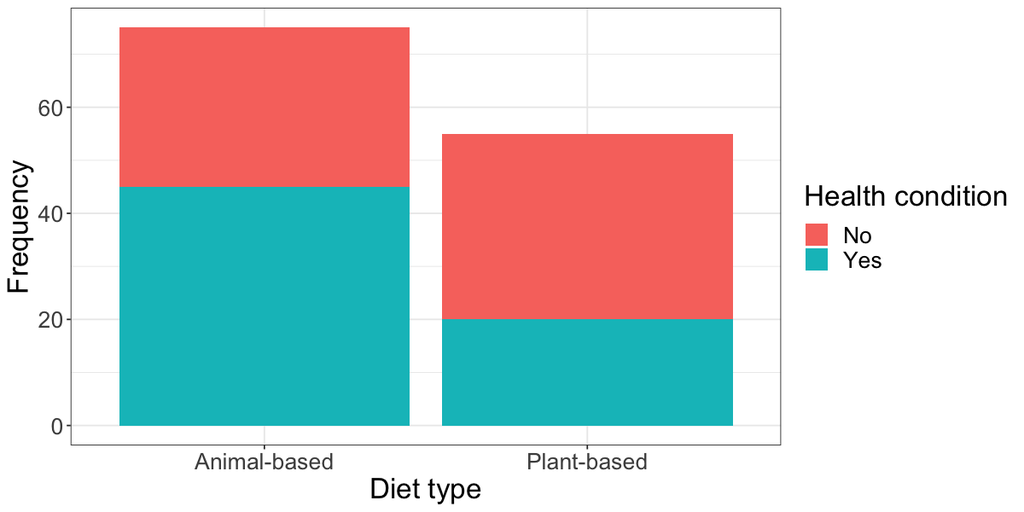

```r
# Create a data frame with the bivariate frequency table data
data <- data.frame(
    Diet_Type = c("Plant-based", "Plant-based", "Animal-based", "Animal-based"),
    Health_Condition = c("Yes", "No", "Yes", "No"),
    Frequency = c(20, 35, 45, 30)
)

# Create the stacked bar chart
g <- ggplot(data, aes(x = Diet_Type, y = Frequency, fill = Health_Condition)) +
    geom_bar(stat = "identity") +
    labs(x = "Diet type", y = "Frequency", fill = "Health condition") +
    theme_bw() +
    theme(text = element_text(size = 20))
options(repr.plot.width=10, repr.plot.height=5)
g
```

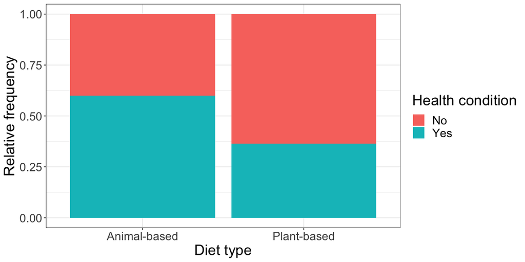

```r
# Calculate relative frequencies within each diet type
data <- transform(data, Relative_Frequency = Frequency / tapply(Frequency, Diet_Type, sum)[Diet_Type])

# Create the stacked relative frequency bar chart
g <- ggplot(data, aes(x = Diet_Type, y = Relative_Frequency, fill = Health_Condition)) +
    geom_bar(stat = "identity") +
    labs(x = "Diet type", y = "Relative frequency", fill = "Health condition") +
    theme_bw() +
    theme(text = element_text(size = 20))
options(repr.plot.width=10, repr.plot.height=5)
g
```

### Numeric-categorical relationships

- Side-by-side boxplots of radish growth under three conditions: constant darkness, half light–half darkness, and constant light.

[figure not shown]

### Numeric-numeric relationships

- scatterplot

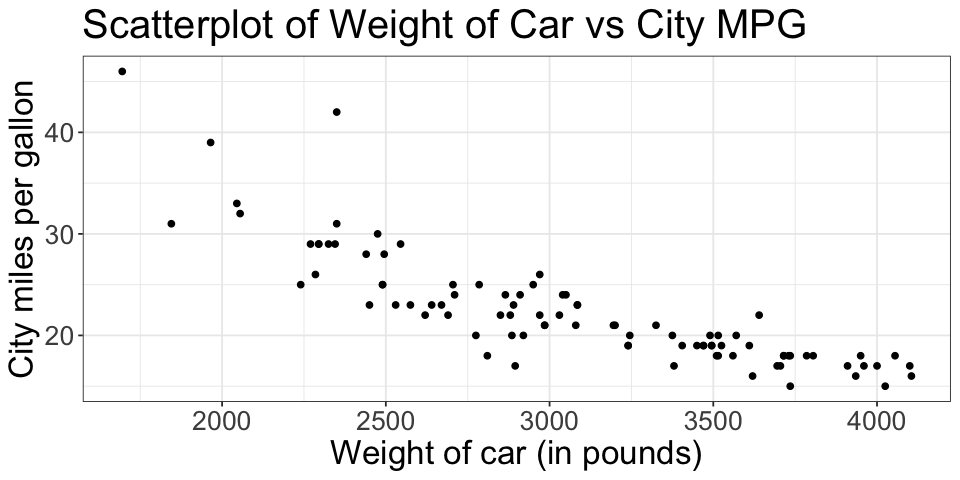

```r
library(MASS)

g <- ggplot(data = Cars93, aes(x = Weight, y = MPG.city)) +
    geom_point() +
    labs(title = "Scatterplot of Weight of Car vs City MPG",
             x = "Weight of car (in pounds)",
             y = "City miles per gallon")+
    theme_bw() +
    theme(text = element_text(size = 20))
options(repr.plot.width=8, repr.plot.height=4)
g
```

## Measures of Dispersion

- We have considered the shapes and centers of distributions, but a good description of a distribution should also characterize how spread out the distribution is; are the observations in the sample all nearly equal, or do they differ substantially?
- We defined the interquartile range (IQR) in previous section, which is one measure of dispersion. Here we consider other measures of dispersion: the range and the standard deviation.

### The range

The sample **range** is the difference between the largest and smallest observations in a sample.

Recall the blood pressure data: The systolic blood pressures (mm Hg) of seven middle-aged men were as follows:

151 124 132 170 146 124 113

- The range is easy to calculate, but it is very sensitive to extreme values; that is, it is not robust.
- Unlike the range, the IQR is robust.

### The standard deviation

The standard deviation is the classical and most widely used measure of dispersion. The sample standard deviation is denoted by $s$ and is defined by the following formula: $$s=\sqrt{\frac{1}{n-1}\sum_{i=1}^n(y_i-\bar{y})^2}.$$ Here $y_i-\bar{y}$ is called the deviation between observation $y_i$, and the sample mean and $\sum_{i=1}^n(y_i-\bar{y})^2$ denotes the sum of the squared deviations.

We will frequently abbreviate "standard deviation" as "SD"; the symbol "s" will be used in formulas.

### Example: chrysanthemum growth

In an experiment on chrysanthemums, a botanist measured the stem elongation (mm in 7 days) of five plants grown on the same greenhouse bench. The results were as follows:

76 72 65 70 82

| Observation | Deviation | Squared deviation |
| --- | --- | --- |
| 76 |  |  |
| 72 |  |  |
| 65 |  |  |
| 70 |  |  |
| 82 |  |  |
| Sum |  |  |

### Interpretation of the definition of $s$

If the chrysanthemum growth data are

75 72 73 75 70

then the mean is the same (y = 73 mm), but the SD is smaller (s = 2.1 mm), because the observations lie closer to the mean.

[figure not shown]

Why $n-1$?

Note that the sum of the deviations $y_i-y$ is always zero. Thus, once the first $n-1$ deviations have been calculated, the last deviation is constrained. This means that in a sample with n observations, there are only $n-1$ units of information concerning deviation from the average. The quantity $n-1$ is called the **degrees of freedom** of the standard deviation or variance.

Consider the extreme case when $n=1$ and $n=2$ with $y_1=y_2$.

### The Empirical Rule

For "nicely shaped" distributions; that is, unimodal distributions that are not too skewed and whose tails are not overly long or short, we usually expect to find

- about 68% of the observations within $\pm1$ SD of the mean.
- about 95% of the observations within $\pm2$ SDs of the mean.
- >99% of the observations within $\pm3$ SDs of the mean.

[figure not shown]

```r
options(repr.plot.width=10, repr.plot.height=5)
g
```

Robustness: IQR > SD > range

In this course, we will rely primarily on the mean and SD rather than other descriptive measures.

## Effect of Transformation of Variables

For example, we might convert from inches to centimeters or from °F to °C. Transformation, or reexpression, of a variable $Y$ means replacing $Y$ by a new variable, say $Y'$.

### Linear transformations

For linear transformations, a graph of $Y$ against $Y'$ would be a straight line. A familiar reason for linear transformation is a change in the scale of measurement.

- Multiplicative transformations: Suppose $Y$ represents the weight of an animal in kg, and we decide to reexpress the weight in lb. Then $$Y=\text{Weight in kg}$$ $$Y'=\text{Weight in lb}$$ so $$Y' = 2.2Y$$
- Additive and multiplicative transformations: $$Y=\text{Temperature in °C}$$ $$Y'=\text{Temperature in °F}$$ then $$Y' = 1.8Y+32$$

A linear transformation consists of (1) multiplying all the observations by a constant, or (2) adding a constant to all the observations, or (3) both.

Under a linear transformation $Y'=aY+b$,

- $\bar{y}'=a\bar{y}+b$
- $\tilde{y}'=a\tilde{y}+b$
- $s'=as$
- $\mathrm{IQR}'=a\mathrm{IQR}$

### Nonlinear transformations

Data are sometimes reexpressed in a nonlinear way. Examples of nonlinear transformations are

- $Y'=\sqrt{Y}$
- $Y'=\log Y$
- $Y'=\frac{1}{Y}$
- $Y'=Y^2$
- The logarithmic transformation is especially common in biology because many important relationships can be simply expressed in terms of logs. For instance, there is a phase in the growth of a bacterial colony when log(colony size) increases at a constant rate with time.
- If a distribution is skewed to the right, we may wish to apply a transformation that makes the distribution more symmetric, by pulling in the right-hand tail. Using $Y' = \sqrt{Y}$ will pull in the right-hand tail of a distribution and push out the left-hand tail. The transformation $Y'=\log Y$ is more severe than $\sqrt{Y}$ in this regard.

[figure not shown]

## Statistical Inference

The process of drawing conclusions about a population, based on observations in a sample from that population, is called statistical inference.

### Example: blood types

In an early study of the ABO blood-typing system, researchers determined blood types of 3,696 persons in England.

| Blood type | Frequency |
| --- | --- |
| A | 1,634 |
| B | 327 |
| AB | 119 |
| O | 1,616 |
| Total | 3,696 |

These data were not collected for the purpose of learning about the blood types of those particular 3,696 people. Rather, they were collected for their scientific value as a source of information about the distribution of blood types in a larger population. For instance, one might presume that the blood type distribution of all English people should resemble the distribution for these 3,696 people. In particular, the observed relative frequency of type A blood was $$\frac{1634}{3696}\text{ or }44\%\text{ type A}$$ One might conclude from this that approximately 44% of the people in England have type A blood.

[figure not shown]

In making a statistical inference, we hope that

- the sample is representative of the population.
- the sample size cannot be too small.

### Describing a population

- Just as each sample has a distribution, a mean, and an SD, so also we can envision a population distribution, a population mean, and a population SD.
- In statistical language, we say that the sample characteristic is an estimate of the corresponding population characteristic.
- A sample characteristic is called a **statistic**; a population characteristic is called a **parameter**.

#### Proportions

For a categorical variable, we can describe a population by simply stating the proportion, or relative frequency, of the population in each category. The sample proportion of a category is an estimate of the corresponding population proportion.

$$p=\text{ Population proportion}$$

$$\hat{p}=\text{ Sample proportion}$$

The symbol "^" can be interpreted as "estimate of". Thus, $$\hat{p}\text{ is an estimate of }p$$

#### Mean and SD

If the observed variable is quantitative, one can consider descriptive measures such as the mean, the SD, the median, the quartiles and so on. Each of these quantities can be computed for a sample of data, and each is an estimate of its corresponding population analog.

The population mean is denoted by $\mu$ (mu), and the population SD is denoted by $\sigma$ (sigma). We may define these as follows for a quantitative variable $Y$: $$\mu=\text{ Population average value of }Y$$ $$\sigma = \sqrt{\text{Population average value of }(Y-\mu)^2}$$

| Measure | Sample value (statistics) | Population value (parameter) |
| --- | --- | --- |
| Proportion | $\hat{p}$ | $p$ |
| Mean | $\bar{y}$ | $\mu$ |
| Standard deviation | $s$ | $\sigma$ |